# Ch3 Applied 9 vs

Adam Prado 2/21/24 Chapter 3 Applied #9, in R

Installing the libraries

```r
library(ISLR2)
library(MASS)
```

8. Viewing the data for Auto

```r
head(Auto)
```

```
##   mpg cylinders displacement horsepower weight acceleration year origin
## 1  18         8          307        130   3504         12.0   70      1
## 2  15         8          350        165   3693         11.5   70      1
## 3  18         8          318        150   3436         11.0   70      1
## 4  16         8          304        150   3433         12.0   70      1
## 5  17         8          302        140   3449         10.5   70      1
## 6  15         8          429        198   4341         10.0   70      1
##                        name
## 1 chevrolet chevelle malibu
## 2         buick skylark 320
## 3        plymouth satellite
## 4             amc rebel sst
## 5               ford torino
## 6          ford galaxie 500
```

1. Scatterplot matrix for each pair of variables, not including name.

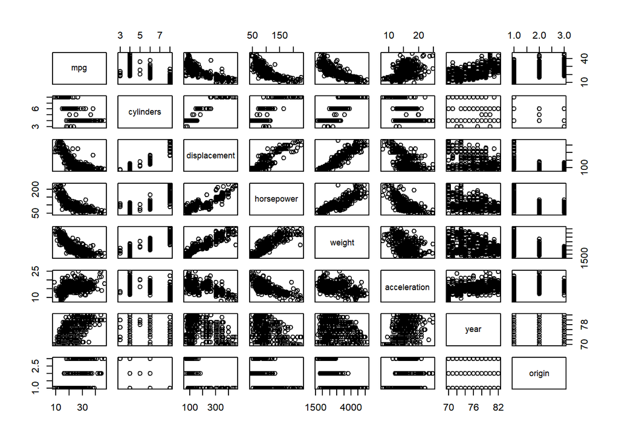

```r
pairs(Auto[1:8])
```

b) Computing the matrix of correlation between each pair of variables, names excluded.

```r
cor(Auto[1:8])
```

```
##                     mpg  cylinders displacement horsepower     weight
## mpg           1.0000000 -0.7776175   -0.8051269 -0.7784268 -0.8322442
## cylinders    -0.7776175  1.0000000    0.9508233  0.8429834  0.8975273
## displacement -0.8051269  0.9508233    1.0000000  0.8972570  0.9329944
## horsepower   -0.7784268  0.8429834    0.8972570  1.0000000  0.8645377
## weight       -0.8322442  0.8975273    0.9329944  0.8645377  1.0000000
## acceleration  0.4233285 -0.5046834   -0.5438005 -0.6891955 -0.4168392
## year          0.5805410 -0.3456474   -0.3698552 -0.4163615 -0.3091199
## origin        0.5652088 -0.5689316   -0.6145351 -0.4551715 -0.5850054
##              acceleration       year     origin
## mpg             0.4233285  0.5805410  0.5652088
## cylinders      -0.5046834 -0.3456474 -0.5689316
## displacement   -0.5438005 -0.3698552 -0.6145351
## horsepower     -0.6891955 -0.4163615 -0.4551715
## weight         -0.4168392 -0.3091199 -0.5850054
## acceleration    1.0000000  0.2903161  0.2127458
## year            0.2903161  1.0000000  0.1815277
## origin          0.2127458  0.1815277  1.0000000
```

Note on b) There are several variables that are highly correlated with each other.

3. multi linear regression with mpg as response and all variables except name as predictors

```r
lm.fit<-lm(mpg~. - name, data=Auto)
summary(lm.fit)
```

```
##
## Call:
## lm(formula = mpg ~ . - name, data = Auto)
##
## Residuals:
##     Min      1Q  Median      3Q     Max
## -9.5903 -2.1565 -0.1169  1.8690 13.0604
##
## Coefficients:
##                Estimate Std. Error t value Pr(>|t|)
## (Intercept)  -17.218435   4.644294  -3.707  0.00024 ***
## cylinders     -0.493376   0.323282  -1.526  0.12780
## displacement   0.019896   0.007515   2.647  0.00844 **
## horsepower    -0.016951   0.013787  -1.230  0.21963
## weight        -0.006474   0.000652  -9.929  < 2e-16 ***
## acceleration   0.080576   0.098845   0.815  0.41548
## year           0.750773   0.050973  14.729  < 2e-16 ***
## origin         1.426141   0.278136   5.127 4.67e-07 ***
## ---
## Signif. codes:  0 '***' 0.001 '**' 0.01 '*' 0.05 '.' 0.1 ' ' 1
##
## Residual standard error: 3.328 on 384 degrees of freedom
## Multiple R-squared:  0.8215, Adjusted R-squared:  0.8182
## F-statistic: 252.4 on 7 and 384 DF,  p-value: < 2.2e-16
```

4. Is there are relationship between predictors and response? Yes, there is a rather strong relationship between them. The Adjusted R^2 is .818, which is quite high and so the variables account for much of mpg’s value. The p-value is also increadibly close to 0, showing that the variables are significant.
2. Which predictors appear to have a statistrically significant reationship to the response? The intercept, weight, year and origin all have very low p-values, so they are very clearly statistically significant. The displacement variable also has a p-value below .01 so it is also has a significant relationship with the response. The variables for cylinders, horsepower and acceleration are not statistically significant. Note: the origin variables is treated as a numeric variable, but in reality it is a categorical one representing production region. It would probably be best to change this into a set of dummy variables.
3. What does the coefficient for the year variables suggest? The coefficient for year of 0.75 suggests that for each year newer(increase in the year manufcatured) the car is, the miles/gallon increases by 0.75mpg. This makes since as newer cars tend to include newer technology to make them more fuel efficient.
4. Plots of the 4 diagnostic plots of the linear regression fit.

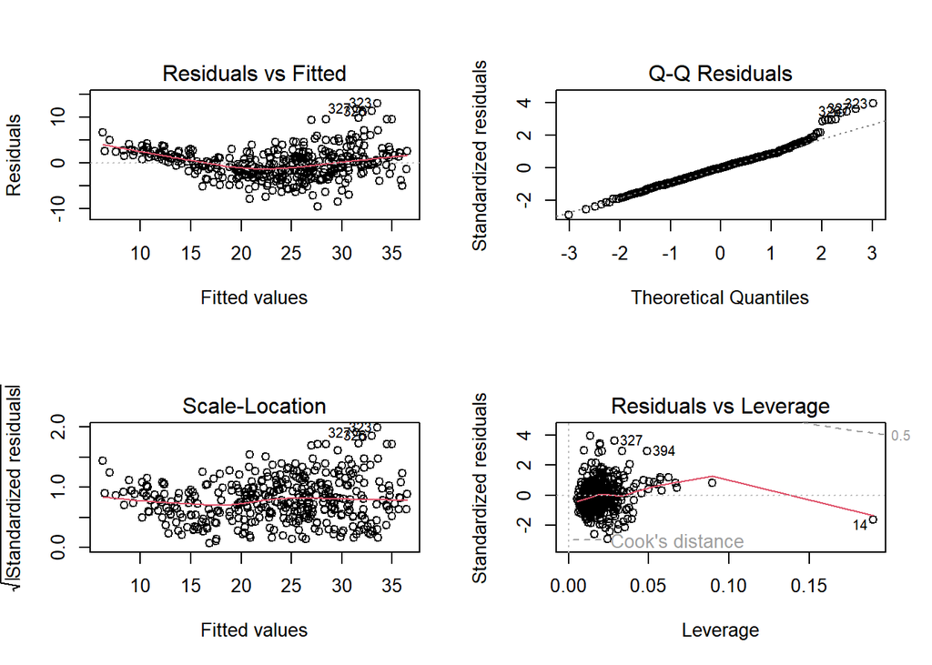

```r
par(mfrow = c(2,2))
plot(lm.fit)
```

Here is the same plots just showing one at a time for better visibility.

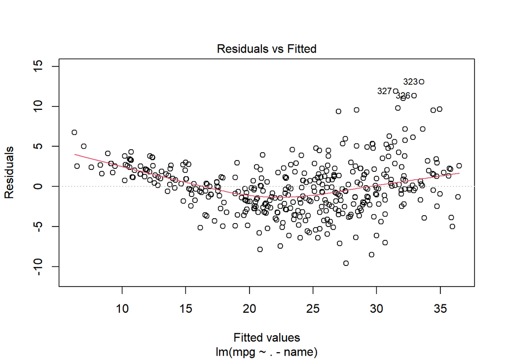

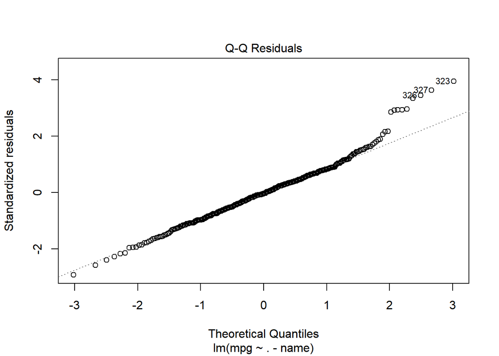

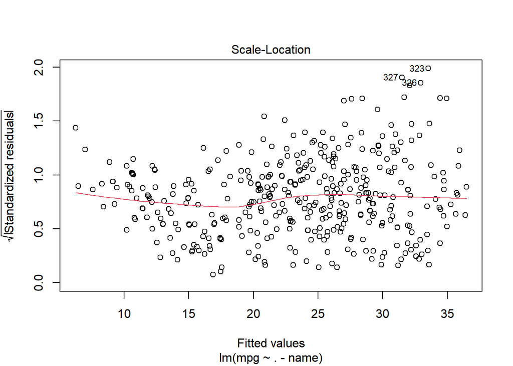

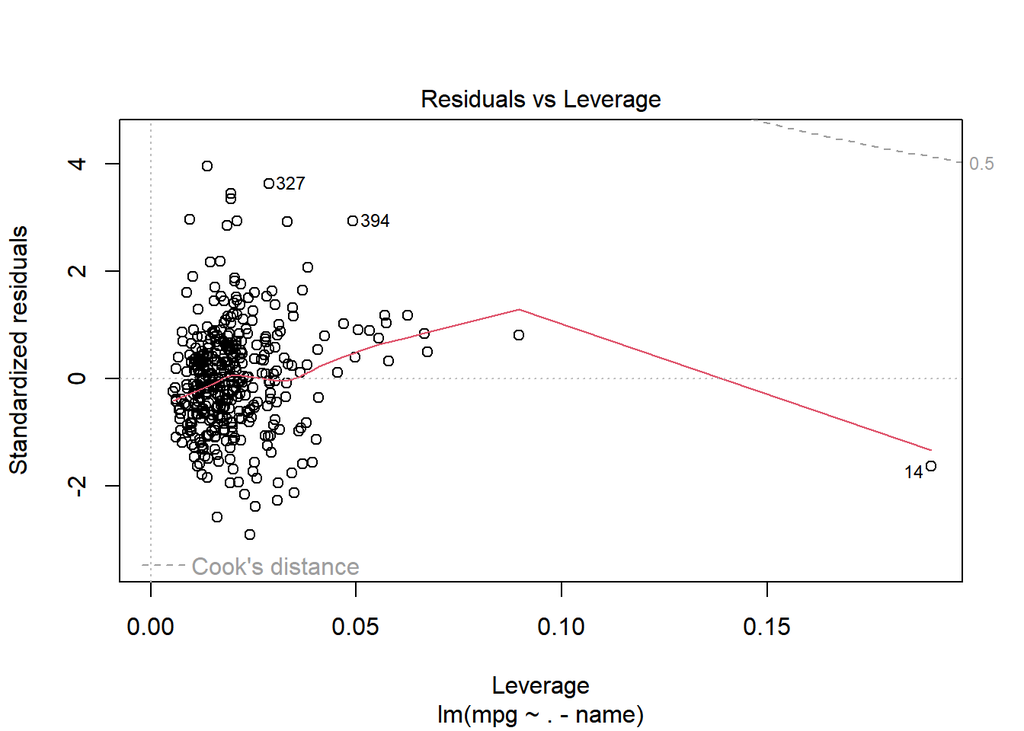

```r
plot(lm.fit)
```

Here is a print out of the high leverage and high residual outliers. Observations: 14, 323, 326, 327

```r
Auto[c(14,321:327),]
```

```
##      mpg cylinders displacement horsepower weight acceleration year origin
## 14  14.0         8          455        225   3086         10.0   70      1
## 323 46.6         4           86         65   2110         17.9   80      3
## 324 27.9         4          156        105   2800         14.4   80      1
## 325 40.8         4           85         65   2110         19.2   80      3
## 326 44.3         4           90         48   2085         21.7   80      2
## 327 43.4         4           90         48   2335         23.7   80      2
## 328 36.4         5          121         67   2950         19.9   80      2
## 329 30.0         4          146         67   3250         21.8   80      2
##                        name
## 14  buick estate wagon (sw)
## 323               mazda glc
## 324              dodge colt
## 325              datsun 210
## 326    vw rabbit c (diesel)
## 327      vw dasher (diesel)
## 328     audi 5000s (diesel)
## 329      mercedes-benz 240d
```

4. Reflection There is a slight pattern in the residual graph, which suggests that a standard linear model might not be the best fit. Perhaps a polynomial fit better, or some model that takes into account variable interactions. There are a few outliers on the residual plot (323, 326 and 327). When examining the data they all have very high mpg, 2 of them are diesel image (perhaps diesel could be an important variable worth exploring?) There is one high leverage point (14) the ’70 buick estate wagon. It has a huge engine and relative to other cars with simialar engine size, has much lower weight but very poor mpg. This makes it a much higher leverage than any other car.

e)Linear regression models with interaction effects, sevarl different combinations tested. The models are named lm.fit1 to lm.fit7

```r
lm.fit1 <- lm(mpg~displacement*weight, data=Auto)
summary(lm.fit1)
```

```
##
## Call:
## lm(formula = mpg ~ displacement * weight, data = Auto)
##
## Residuals:
##      Min       1Q   Median       3Q      Max
## -13.8664  -2.4801  -0.3355   1.8071  17.9429
##
## Coefficients:
##                       Estimate Std. Error t value Pr(>|t|)
## (Intercept)          5.372e+01  1.940e+00  27.697  < 2e-16 ***
## displacement        -7.831e-02  1.131e-02  -6.922 1.85e-11 ***
## weight              -8.931e-03  8.474e-04 -10.539  < 2e-16 ***
## displacement:weight  1.744e-05  2.789e-06   6.253 1.06e-09 ***
## ---
## Signif. codes:  0 '***' 0.001 '**' 0.01 '*' 0.05 '.' 0.1 ' ' 1
##
## Residual standard error: 4.097 on 388 degrees of freedom
## Multiple R-squared:  0.7265, Adjusted R-squared:  0.7244
## F-statistic: 343.6 on 3 and 388 DF,  p-value: < 2.2e-16
```

```r
lm.fit2 <- lm(mpg~year*weight, data=Auto)
summary(lm.fit2)
```

```
##
## Call:
## lm(formula = mpg ~ year * weight, data = Auto)
##
## Residuals:
##     Min      1Q  Median      3Q     Max
## -8.0397 -1.9956 -0.0983  1.6525 12.9896
##
## Coefficients:
##               Estimate Std. Error t value Pr(>|t|)
## (Intercept) -1.105e+02  1.295e+01  -8.531 3.30e-16 ***
## year         2.040e+00  1.718e-01  11.876  < 2e-16 ***
## weight       2.755e-02  4.413e-03   6.242 1.14e-09 ***
## year:weight -4.579e-04  5.907e-05  -7.752 8.02e-14 ***
## ---
## Signif. codes:  0 '***' 0.001 '**' 0.01 '*' 0.05 '.' 0.1 ' ' 1
##
## Residual standard error: 3.193 on 388 degrees of freedom
## Multiple R-squared:  0.8339, Adjusted R-squared:  0.8326
## F-statistic: 649.3 on 3 and 388 DF,  p-value: < 2.2e-16
```

```r
lm.fit3 <- lm(mpg~year*horsepower, data=Auto)
summary(lm.fit3)
```

```
##
## Call:
## lm(formula = mpg ~ year * horsepower, data = Auto)
##
## Residuals:
##      Min       1Q   Median       3Q      Max
## -12.3492  -2.4509  -0.4557   2.4056  14.4437
##
## Coefficients:
##                   Estimate Std. Error t value Pr(>|t|)
## (Intercept)     -1.266e+02  1.212e+01 -10.449   <2e-16 ***
## year             2.192e+00  1.613e-01  13.585   <2e-16 ***
## horsepower       1.046e+00  1.154e-01   9.063   <2e-16 ***
## year:horsepower -1.596e-02  1.562e-03 -10.217   <2e-16 ***
## ---
## Signif. codes:  0 '***' 0.001 '**' 0.01 '*' 0.05 '.' 0.1 ' ' 1
##
## Residual standard error: 3.901 on 388 degrees of freedom
## Multiple R-squared:  0.7522, Adjusted R-squared:  0.7503
## F-statistic: 392.5 on 3 and 388 DF,  p-value: < 2.2e-16
```

```r
lm.fit4 <- lm(mpg~ year*weight + year*displacement, data=Auto)
summary(lm.fit4)
```

```
##
## Call:
## lm(formula = mpg ~ year * weight + year * displacement, data = Auto)
##
## Residuals:
##     Min      1Q  Median      3Q     Max
## -8.1968 -2.0185 -0.1259  1.6376 12.9734
##
## Coefficients:
##                     Estimate Std. Error t value Pr(>|t|)
## (Intercept)       -1.173e+02  1.781e+01  -6.584  1.5e-10 ***
## year               2.124e+00  2.376e-01   8.941  < 2e-16 ***
## weight             3.287e-02  1.064e-02   3.090 0.002146 **
## displacement      -4.058e-02  8.381e-02  -0.484 0.628504
## year:weight       -5.224e-04  1.424e-04  -3.668 0.000278 ***
## year:displacement  4.827e-04  1.127e-03   0.428 0.668679
## ---
## Signif. codes:  0 '***' 0.001 '**' 0.01 '*' 0.05 '.' 0.1 ' ' 1
##
## Residual standard error: 3.196 on 386 degrees of freedom
## Multiple R-squared:  0.8345, Adjusted R-squared:  0.8323
## F-statistic: 389.2 on 5 and 386 DF,  p-value: < 2.2e-16
```

```r
lm.fit5 <- lm(mpg~year*weight + displacement, data=Auto)
summary(lm.fit5)
```

```
##
## Call:
## lm(formula = mpg ~ year * weight + displacement, data = Auto)
##
## Residuals:
##     Min      1Q  Median      3Q     Max
## -8.1662 -2.0127 -0.1487  1.6086 12.9559
##
## Coefficients:
##                Estimate Std. Error t value Pr(>|t|)
## (Intercept)  -1.121e+02  1.304e+01  -8.598  < 2e-16 ***
## year          2.054e+00  1.723e-01  11.924  < 2e-16 ***
## weight        2.876e-02  4.557e-03   6.310 7.64e-10 ***
## displacement -4.739e-03  4.460e-03  -1.062    0.289
## year:weight  -4.671e-04  5.968e-05  -7.826 4.87e-14 ***
## ---
## Signif. codes:  0 '***' 0.001 '**' 0.01 '*' 0.05 '.' 0.1 ' ' 1
##
## Residual standard error: 3.193 on 387 degrees of freedom
## Multiple R-squared:  0.8344, Adjusted R-squared:  0.8327
## F-statistic: 487.5 on 4 and 387 DF,  p-value: < 2.2e-16
```

```r
lm.fit6 <- lm(mpg~year*horsepower + year*weight, data=Auto)
summary(lm.fit6)
```

```
##
## Call:
## lm(formula = mpg ~ year * horsepower + year * weight, data = Auto)
##
## Residuals:
##     Min      1Q  Median      3Q     Max
## -7.6922 -1.9713 -0.0949  1.6632 12.5871
##
## Coefficients:
##                   Estimate Std. Error t value Pr(>|t|)
## (Intercept)     -1.106e+02  1.303e+01  -8.484 4.71e-16 ***
## year             2.042e+00  1.729e-01  11.814  < 2e-16 ***
## horsepower       6.240e-01  1.714e-01   3.640 0.000310 ***
## weight           6.921e-03  8.179e-03   0.846 0.398010
## year:horsepower -8.780e-03  2.307e-03  -3.806 0.000164 ***
## year:weight     -1.677e-04  1.088e-04  -1.542 0.123992
## ---
## Signif. codes:  0 '***' 0.001 '**' 0.01 '*' 0.05 '.' 0.1 ' ' 1
##
## Residual standard error: 3.106 on 386 degrees of freedom
## Multiple R-squared:  0.8436, Adjusted R-squared:  0.8416
## F-statistic: 416.5 on 5 and 386 DF,  p-value: < 2.2e-16
```

```r
lm.fit7 <- lm(mpg~year*horsepower + weight, data=Auto)
summary(lm.fit7)
```

```
##
## Call:
## lm(formula = mpg ~ year * horsepower + weight, data = Auto)
##
## Residuals:
##     Min      1Q  Median      3Q     Max
## -7.8511 -2.0608 -0.0204  1.6176 12.6659
##
## Coefficients:
##                   Estimate Std. Error t value Pr(>|t|)
## (Intercept)     -9.740e+01  9.864e+00  -9.874   <2e-16 ***
## year             1.867e+00  1.306e-01  14.301   <2e-16 ***
## horsepower       8.462e-01  9.301e-02   9.097   <2e-16 ***
## weight          -5.675e-03  3.804e-04 -14.919   <2e-16 ***
## year:horsepower -1.174e-02  1.278e-03  -9.190   <2e-16 ***
## ---
## Signif. codes:  0 '***' 0.001 '**' 0.01 '*' 0.05 '.' 0.1 ' ' 1
##
## Residual standard error: 3.112 on 387 degrees of freedom
## Multiple R-squared:  0.8427, Adjusted R-squared:  0.841
## F-statistic: 518.1 on 4 and 387 DF,  p-value: < 2.2e-16
```

6. Trying different transformations of the variables. These models are named lm.fitA to lm.fitE

```r
lm.fitA <-lm(mpg~poly(weight,3), data=Auto)
summary(lm.fitA)
```

```
##
## Call:
## lm(formula = mpg ~ poly(weight, 3), data = Auto)
##
## Residuals:
##      Min       1Q   Median       3Q      Max
## -12.6259  -2.7080  -0.3552   1.8385  16.0816
##
## Coefficients:
##                   Estimate Std. Error t value Pr(>|t|)
## (Intercept)        23.4459     0.2112 111.008  < 2e-16 ***
## poly(weight, 3)1 -128.4436     4.1817 -30.716  < 2e-16 ***
## poly(weight, 3)2   23.1589     4.1817   5.538 5.65e-08 ***
## poly(weight, 3)3    0.2204     4.1817   0.053    0.958
## ---
## Signif. codes:  0 '***' 0.001 '**' 0.01 '*' 0.05 '.' 0.1 ' ' 1
##
## Residual standard error: 4.182 on 388 degrees of freedom
## Multiple R-squared:  0.7151, Adjusted R-squared:  0.7129
## F-statistic: 324.7 on 3 and 388 DF,  p-value: < 2.2e-16
```

```r
lm.fitB<-lm(mpg~log(weight), data=Auto)
summary(lm.fitB)
```

```
##
## Call:
## lm(formula = mpg ~ log(weight), data = Auto)
##
## Residuals:
##      Min       1Q   Median       3Q      Max
## -12.4315  -2.6752  -0.2888   1.9429  16.0136
##
## Coefficients:
##             Estimate Std. Error t value Pr(>|t|)
## (Intercept) 209.9433     6.0002   34.99   <2e-16 ***
## log(weight) -23.4317     0.7534  -31.10   <2e-16 ***
## ---
## Signif. codes:  0 '***' 0.001 '**' 0.01 '*' 0.05 '.' 0.1 ' ' 1
##
## Residual standard error: 4.189 on 390 degrees of freedom
## Multiple R-squared:  0.7127, Adjusted R-squared:  0.7119
## F-statistic: 967.3 on 1 and 390 DF,  p-value: < 2.2e-16
```

```r
lm.fitC<-lm(mpg~sqrt(weight), data=Auto)
summary(lm.fitC)
```

```
##
## Call:
## lm(formula = mpg ~ sqrt(weight), data = Auto)
##
## Residuals:
##      Min       1Q   Median       3Q      Max
## -12.2402  -2.9005  -0.3708   2.0791  16.2296
##
## Coefficients:
##              Estimate Std. Error t value Pr(>|t|)
## (Intercept)  69.67218    1.52649   45.64   <2e-16 ***
## sqrt(weight) -0.85560    0.02797  -30.59   <2e-16 ***
## ---
## Signif. codes:  0 '***' 0.001 '**' 0.01 '*' 0.05 '.' 0.1 ' ' 1
##
## Residual standard error: 4.239 on 390 degrees of freedom
## Multiple R-squared:  0.7058, Adjusted R-squared:  0.705
## F-statistic: 935.4 on 1 and 390 DF,  p-value: < 2.2e-16
```

```r
lm.fitD<-lm(mpg~poly(year,3), data=Auto)
summary(lm.fitD)
```

```
##
## Call:
## lm(formula = mpg ~ poly(year, 3), data = Auto)
##
## Residuals:
##      Min       1Q   Median       3Q      Max
## -13.2690  -5.0507  -0.8684   4.8333  17.9470
##
## Coefficients:
##                Estimate Std. Error t value Pr(>|t|)
## (Intercept)     23.4459     0.3144  74.568  < 2e-16 ***
## poly(year, 3)1  89.5972     6.2253  14.392  < 2e-16 ***
## poly(year, 3)2  26.9524     6.2253   4.330  1.9e-05 ***
## poly(year, 3)3  -5.3209     6.2253  -0.855    0.393
## ---
## Signif. codes:  0 '***' 0.001 '**' 0.01 '*' 0.05 '.' 0.1 ' ' 1
##
## Residual standard error: 6.225 on 388 degrees of freedom
## Multiple R-squared:  0.3687, Adjusted R-squared:  0.3638
## F-statistic: 75.54 on 3 and 388 DF,  p-value: < 2.2e-16
```

```r
lm.fitE<-lm(mpg~log(year), data=Auto)
summary(lm.fitE)
```

```
##
## Call:
## lm(formula = mpg ~ log(year), data = Auto)
##
## Residuals:
##      Min       1Q   Median       3Q      Max
## -11.8860  -5.5076  -0.4014   4.8925  18.2655
##
## Coefficients:
##             Estimate Std. Error t value Pr(>|t|)
## (Intercept) -377.873     28.803  -13.12   <2e-16 ***
## log(year)     92.699      6.653   13.93   <2e-16 ***
## ---
## Signif. codes:  0 '***' 0.001 '**' 0.01 '*' 0.05 '.' 0.1 ' ' 1
##
## Residual standard error: 6.386 on 390 degrees of freedom
## Multiple R-squared:  0.3324, Adjusted R-squared:  0.3307
## F-statistic: 194.2 on 1 and 390 DF,  p-value: < 2.2e-16
```

While some of the transformations had very low p-values and were statistically significant. None of the models were as good as the ones from the previous section that used variables interactions instead of transformations involving exponents, roots and logs. Some of them had much lower R squared values even though they had low p-values.